# ch01

## 1.4 Reading and writing Waves

thinkdsp provides read_wave, which reads a WAV file and returns a Wave:

```
violin_wave = thinkdsp.read_wave('input.wav')
```

And Wave provides write, which writes a WAV file:

```
wave.write(filename='output.wav')
```

You can listen to the Wave with any media player that plays WAV files. On UNIX systems, I use aplay, which is simple, robust, and included in many Linux distributions.

thinkdsp also provides play_wave, which runs the media player as a subprocess:

```
thinkdsp.play_wave(filename='output.wav', player='aplay')
```

It uses aplay by default, but you can provide the name of another player.

除了在 Python 程式環境中 `製造` 訊號物件之外，還要能夠從外部的資料來源(網路、硬碟)撈取聲音資料。在外 面，是一個 `.wav` 的聲音檔案，我們可以先用外部程式如 Audacity 看一看、聽一聽。然後再讀近來程式環境中，進一步處理。當然，處理完之後，也要能夠回存至硬碟中。

[figure not shown]

```python
w2= td.read_wave('wav/rySpeech001.wav')
w2.duration, w2.framerate, w2.ts, w2.ys
```

```
(6.181927437641724,
 44100,
 array([0.00000000e+00, 2.26757370e-05, 4.53514739e-05, ...,
        6.18185941e+00, 6.18188209e+00, 6.18190476e+00]),
 array([0.00048067, 0.00053407, 0.001442  , ..., 0.00154881, 0.00138859,
        0.00165563]))
```

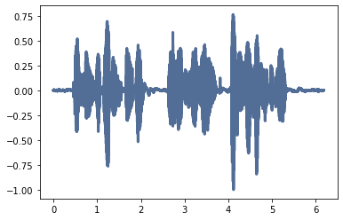

```python
w2.plot()
```

```python
w2.make_audio()
```

[interactive chart not shown]

## 1.5 Spectrums

Wave provides make_spectrum, which returns a `Spectrum`:

```
spectrum = wave.make_spectrum()
```

And Spectrum provides plot:

```
spectrum.plot()
thinkplot.show()
```

thinkplot is a module I wrote to provide wrappers around some of the functions in pyplot. It is included in the Git repository for this book (see Section 0.2).

[figure not shown]

```python
# class Spectrum 繼承了 class _SpectrumParent
# 因此，把 2 個 class 同時一起看一看

print(dir(td._SpectrumParent))
print(dir(td.Spectrum))

_1= {'amps', 'copy', 'estimate_slope', 'freq_res', 'invert', 'max_diff',
'max_freq', 'peaks', 'plot', 'plot_power', 'power', 'ratio', 'render_full'}


_2= {'amps', 'angles', 'band_stop', 'convolve', 'copy', 'differentiate',
'estimate_slope', 'freq_res', 'high_pass', 'imag', 'integrate', 'invert',
'low_pass', 'make_integrated_spectrum', 'make_wave', 'max_diff',
'max_freq', 'peaks', 'pink_filter', 'plot', 'plot_power', 'power',
'ratio', 'real', 'render_full', 'scale'}

# 我們也確認了 父類別 _SpectrumParent 的 methods
# 完全包含於 子類別 Spectrum 之中

_1.issubset(_2)
```

[output not shown]

```
True
```

Spectrum provides three methods that modify the spectrum:

`low_pass` applies a low-pass filter, which means that components above a given cutoff frequency are attenuated (that is, reduced in magnitude) by a factor.

`high_pass` applies a high-pass filter, which means that it attenuates components below the cutoff.

`band_stop` attenuates components in the band of frequencies between two cutoffs. This example attenuates all frequencies above 600 by 99%:

```
spectrum.low_pass(cutoff=600, factor=0.01)
```

- 在此內嵌一段 原始的 python 程式碼片段，
- 大家可以看得更清楚這幾個 methods

```
class Spectrum(_SpectrumParent):
    """Represents the spectrum of a signal."""

    def low_pass(self, cutoff, factor=0):
        """Attenuate frequencies above the cutoff.

        cutoff: frequency in Hz
        factor: what to multiply the magnitude by
        """
        self.hs[abs(self.fs) > cutoff] *= factor

    def high_pass(self, cutoff, factor=0):
        """Attenuate frequencies below the cutoff.

        cutoff: frequency in Hz
        factor: what to multiply the magnitude by
        """
        self.hs[abs(self.fs) < cutoff] *= factor

    def band_stop(self, low_cutoff, high_cutoff, factor=0):
        """Attenuate frequencies between the cutoffs.

        low_cutoff: frequency in Hz
        high_cutoff: frequency in Hz
        factor: what to multiply the magnitude by
        """
        # TODO: test this function
        fs = abs(self.fs)
        indices = (low_cutoff < fs) & (fs < high_cutoff)
        self.hs[indices] *= factor
```

A low-pass filter removes bright, high-frequency sounds, so the result sounds muffled and darker. To hear what it sounds like, you can convert the Spectrum back to a Wave, and then play it.

```
wave = spectrum.make_wave()
wave.play('temp.wav')
```

The play method writes the wave to a file and then plays it. If you use Jupyter notebooks, you can use make_audio, which makes an Audio widget that plays the sound.

- 我們來玩一下。

[interactive chart not shown]

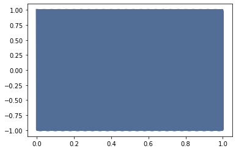

```python
aSignal=    td.CosSignal()
aWave=      aSignal.make_wave()
aWave.plot()
aWave.make_audio()
```

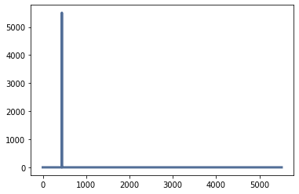

```python
aSpectrum=  aWave.make_spectrum()
aSpectrum.plot()
```

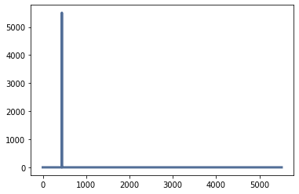

```python
aSpectrum.low_pass(cutoff=500)
aSpectrum.plot()
```

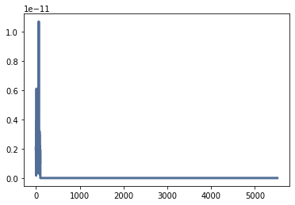

```python
aSpectrum.low_pass(cutoff=400)
aSpectrum.plot()
```

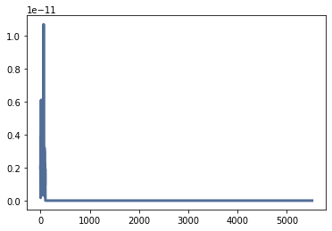

```python
aSpectrum.low_pass(cutoff=100)
aSpectrum.plot()
```

- 至於 被處理過後的信號，我們聽起來有何差異？接下來再說明。

## 1.6 Wave objects

[figure not shown]

Figure 1.5: Relationships among the classes in thinkdsp.

There is nothing very complicated in thinkdsp.py. Most of the functions it provides are thin wrappers around functions from

- `NumPy` and
- `SciPy`.

The primary classes in thinkdsp are

- `class Signal`,
- `class Wave`, and
- `class Spectrum`.

Given a Signal, you can make a Wave. Given a Wave, you can make a Spectrum, and vice versa. These relationships are shown in Figure 1.5.

A Wave object contains three `attributes`:

- ys
  - is a NumPy array that contains the values in the signal;
- ts
  - is an array of the times where the signal was evaluated or sampled; and
- framerate
  - is the number of samples per unit of time.

The unit of time is usually seconds, but it doesn’t have to be. In one of my examples, it’s days.

Wave also provides three `read-only properties`:

- start
- end
- duration

If you modify ts, these properties change accordingly.

To modify a wave, you can access the ts and ys directly.

For example:

```
wave.ys *= 2
wave.ts += 1
```

- The first line scales the wave by a factor of 2, making it louder.
- The second line shifts the wave in time, making it start 1 second later.

But Wave provides methods that perform many common operations.

For example, the same two transformations could be written:

```
wave.scale(2)
wave.shift(1)
```

You can read the documentation of these methods and others at http://greenteapress.com/thinkdsp.html.

## 1.7 Signal objects

`class Signal` is a parent class that provides functions common to all kinds of signals, like make_wave. Child classes inherit these methods and provide `evaluate`, which evaluates the signal at a given sequence of times.

For example, `class Sinusoid` is a child class of `class Signal`, with this definition:

```
class Sinusoid(Signal):

    def __init__(self, freq=440, amp=1.0, offset=0, func=np.sin):
        Signal.__init__(self)
        self.freq = freq
        self.amp = amp
        self.offset = offset
        self.func = func
```

The parameters of `__init__` are:

- freq:
  - frequency in cycles per second, or Hz.
- amp:
  - amplitude. The units of amplitude are arbitrary, usually chosen so 1.0 corresponds to the maximum input from a microphone or maximum output to a speaker.
- offset:
  - indicates where in its period the signal starts; offset is in units of radians, for reasons I explain below.
- func:
  - a Python function used to evaluate the signal at a particular point in time. It is usually either `np.sin` or `np.cos`, yielding a sine or cosine signal.

Like many init methods, this one just tucks the parameters away for future use.

Signal provides make_wave, which looks like this:

```
def make_wave(self, duration=1, start=0, framerate=11025):
        n = round(duration * framerate)
        ts = start + np.arange(n) / framerate
        ys = self.evaluate(ts)
        return Wave(ys, ts, framerate=framerate)
```

start and duration are the start time and duration in seconds. framerate is the number of frames (samples) per second.

n is the number of samples, and ts is a NumPy array of sample times.

To compute the ys, make_wave invokes evaluate, which is provided by Sinusoid:

```
def evaluate(self, ts):
        phases = PI2 * self.freq * ts + self.offset
        ys = self.amp * self.func(phases)
        return ys
```

Let’s unwind this function one step at time:

- self.freq
  - is frequency in cycles per second, and each element of ts is a time in seconds, so their product is the number of cycles since the start time.
- PI2
  - is a constant that stores 2 π. Multiplying by PI2 converts from cycles to phase. You can think of phase as “cycles since the start time” expressed in radians. Each cycle is 2 π radians.
- self.offset
  - is the phase when t=0. It has the effect of shifting the signal left or right in time.

If `self.func` is `np.sin` or `np.cos`, the result is a value between −1 and +1. Multiplying by `self.amp` yields a signal that ranges from -self.amp to +self.amp.

In math notation, evaluate is written like this:

$ y = A cos(2 π f t + φ_0) $

where,

- A is amplitude,
- f is frequency,
- t is time, and
- $φ_0$ is the phase offset.

It may seem like I wrote a lot of code to evaluate one simple expression, but as we’ll see, this code provides a framework for dealing with all kinds of signals, not just sinusoids.

## 1.8 Exercises

Before you begin these exercises, you should download the code for this book, following the instructions in Section 0.2.

Solutions to these exercises are in chap01soln.ipynb.

Exercise 1

If you have Jupyter, load chap01.ipynb, read through it, and run the examples. You can also view this notebook at http://tinyurl.com/thinkdsp01.

Exercise 2

Go to http://freesound.org and download a sound sample that includes music, speech, or other sounds that have a well-defined pitch. Select a roughly half-second segment where the pitch is constant. Compute and plot the spectrum of the segment you selected. What connection can you make between the timbre of the sound and the harmonic structure you see in the spectrum? Use high_pass, low_pass, and band_stop to filter out some of the harmonics. Then convert the spectrum back to a wave and listen to it. How does the sound relate to the changes you made in the spectrum?

Exercise 3

Synthesize a compound signal by creating SinSignal and CosSignal objects and adding them up. Evaluate the signal to get a Wave, and listen to it. Compute its Spectrum and plot it. What happens if you add frequency components that are not multiples of the fundamental?

Exercise 4

Write a function called stretch that takes a Wave and a stretch factor and speeds up or slows down the wave by modifying ts and framerate. Hint: it should only take two lines of code.

# An exercise a day, Keep the teacher away ~~~

an Exercise by the teacher

- 開始做習題，以 .ipynb 的形式，先放在你自己的硬碟上，
- 接下來學習如何放在 Github 上，再告訴老師你的 連結。